# Project: Medical Appointments in Brazil

- Introduction
- Data Wrangling
- Exploratory Data Analysis
- Research Question 1
- Research Question 2
- Research Question 3
- Limitations and Conclusion

## Introduction

### For this Project, I chose the ['no-show'](https://www.kaggle.com/joniarroba/noshowappointments) Dataset from Kaggle, describing medical Patients charasteristics and whether or not they showed up to the Appointment(s) they had arranged. I want to investigate which of the Characteristics of the Patients influence the Result of showing up to their Appointment(s). The goal could be to be able to predict wether a Patient would be inclined to miss its Appointment and find a Strategy to prevent this.

### I will investigate specifically the independent Variables for the Age, Gender and Location and try and find if they have an Influence on the Dependent Variable that we are analyzing.

```python
# Import statements for all of the packages I will be using: Pandas, Matplotlib, Seaborn

import pandas as pd
import matplotlib.pyplot as plt
import seaborn as sns
import numpy as np

%matplotlib inline
```

## Data Wrangling

### General Properties

```python
# Load the data and print out a few lines. Perform operations to inspect data
#   types and look for instances of missing or possibly errant data.
df_appointments = pd.read_csv('appointments.csv')
df_appointments.head()
```

|  | PatientId | AppointmentID | Gender | ScheduledDay | AppointmentDay | Age | Neighbourhood | Scholarship | Hipertension | Diabetes | Alcoholism | Handcap | SMS_received | No-show |
| --- | --- | --- | --- | --- | --- | --- | --- | --- | --- | --- | --- | --- | --- | --- |
| 0 | 2.987250e+13 | 5642903 | F | 2016-04-29T18:38:08Z | 2016-04-29T00:00:00Z | 62 | JARDIM DA PENHA | 0 | 1 | 0 | 0 | 0 | 0 | No |
| 1 | 5.589978e+14 | 5642503 | M | 2016-04-29T16:08:27Z | 2016-04-29T00:00:00Z | 56 | JARDIM DA PENHA | 0 | 0 | 0 | 0 | 0 | 0 | No |
| 2 | 4.262962e+12 | 5642549 | F | 2016-04-29T16:19:04Z | 2016-04-29T00:00:00Z | 62 | MATA DA PRAIA | 0 | 0 | 0 | 0 | 0 | 0 | No |
| 3 | 8.679512e+11 | 5642828 | F | 2016-04-29T17:29:31Z | 2016-04-29T00:00:00Z | 8 | PONTAL DE CAMBURI | 0 | 0 | 0 | 0 | 0 | 0 | No |
| 4 | 8.841186e+12 | 5642494 | F | 2016-04-29T16:07:23Z | 2016-04-29T00:00:00Z | 56 | JARDIM DA PENHA | 0 | 1 | 1 | 0 | 0 | 0 | No |

I further inspect the dataframe for characteristics and cleanliness:

```python
df_appointments.shape
```

```
(110527, 14)
```

```python
df_appointments.PatientId.nunique()
```

```
62299
```

```python
df_appointments.info()
```

```
<class 'pandas.core.frame.DataFrame'>
RangeIndex: 110527 entries, 0 to 110526
Data columns (total 14 columns):
PatientId         110527 non-null float64
AppointmentID     110527 non-null int64
Gender            110527 non-null object
ScheduledDay      110527 non-null object
AppointmentDay    110527 non-null object
Age               110527 non-null int64
Neighbourhood     110527 non-null object
Scholarship       110527 non-null int64
Hipertension      110527 non-null int64
Diabetes          110527 non-null int64
Alcoholism        110527 non-null int64
Handcap           110527 non-null int64
SMS_received      110527 non-null int64
No-show           110527 non-null object
dtypes: float64(1), int64(8), object(5)
memory usage: 11.8+ MB
```

```python
print('Number of Duplicates: {0}'.format(sum(df_appointments.duplicated())))
df_appointments.isnull().any()
```

```
Number of Duplicates: 0
```

```
PatientId         False
AppointmentID     False
Gender            False
ScheduledDay      False
AppointmentDay    False
Age               False
Neighbourhood     False
Scholarship       False
Hipertension      False
Diabetes          False
Alcoholism        False
Handcap           False
SMS_received      False
No-show           False
dtype: bool
```

#### Check for Duplicates in the Appointment ID

```python
df_appointments.AppointmentID.duplicated().sum()
```

```
0
```

### First Impression of the state of the Data and possible Problems:

So far there is no obvious Problem with the data: there are no missing values, no row duplicates, and no inconsistency(we checked to see if the 'AppointmentID' Column, identifying each Appointment Record, had any Duplicates).

### Cleaning:

The Data is already very clean. I will still change the format of the Dates to get time stamp formats. I will also change the name of the Column 'No-show' in 'Missed', to be sure I won't mistaken the meaning of the Values ('True' means the Patient did not show up, 'False' means the Patient came)

```python
#Types of dates

type(df_appointments.AppointmentDay[0])
type(df_appointments.ScheduledDay[0])

#cast to timestamp
df_appointments.AppointmentDay = pd.to_datetime(df_appointments.AppointmentDay)
df_appointments.ScheduledDay = pd.to_datetime(df_appointments.ScheduledDay)

#rename 'No-show' Column to avoid later Confusions
df_appointments.rename(columns={'No-show':'Missed'}, inplace=True)
```

I will sort the dataset from the AppointmentID, to keep the chronological order, the Appointments were taken in the system (it should be the same than ordering by the Scheduled Day). I also reset the index for a clearer view of the dataset.

```python
df_appointments.sort_values(['AppointmentID'], inplace=True)
df_appointments.reset_index(drop=True,inplace=True)
df_appointments.tail(5)
```

|  | PatientId | AppointmentID | Gender | ScheduledDay | AppointmentDay | Age | Neighbourhood | Scholarship | Hipertension | Diabetes | Alcoholism | Handcap | SMS_received | Missed |
| --- | --- | --- | --- | --- | --- | --- | --- | --- | --- | --- | --- | --- | --- | --- |
| 110522 | 7.292552e+14 | 5790461 | M | 2016-06-08 19:32:25 | 2016-06-08 | 54 | JARDIM CAMBURI | 0 | 0 | 0 | 0 | 0 | 0 | No |
| 110523 | 9.476144e+14 | 5790464 | F | 2016-06-08 19:32:56 | 2016-06-08 | 43 | JARDIM CAMBURI | 0 | 0 | 0 | 0 | 0 | 0 | No |
| 110524 | 3.562479e+11 | 5790466 | M | 2016-06-08 19:33:23 | 2016-06-08 | 27 | JARDIM CAMBURI | 0 | 0 | 0 | 0 | 0 | 0 | No |
| 110525 | 2.341318e+11 | 5790481 | F | 2016-06-08 19:58:52 | 2016-06-08 | 30 | JARDIM CAMBURI | 0 | 0 | 0 | 0 | 0 | 0 | No |
| 110526 | 5.237164e+12 | 5790484 | F | 2016-06-08 20:07:23 | 2016-06-08 | 27 | JARDIM CAMBURI | 0 | 0 | 0 | 0 | 0 | 0 | No |

### Several Appointments for a same Patient: gaining Knowledge about the Data:

I want to get a better idea about several Appointments arranged by the same Patient and how this looks like. Can I recognize any Trends there, like: are there a lot of Patients that "constantly" miss their Appointments and settle new ones? I also want to compare these Appointments to the ones that are "unique" (one Appointment made by one Patient). So I first set a Mask that allows me retrieving the rows where a Patient occurs x number of times and first get all the "multiple" Appointments.

```python
app_per_patient = df_appointments['PatientId'].value_counts()
df_several = df_appointments[df_appointments.PatientId.isin(app_per_patient[app_per_patient > 1].index)]
df_several.shape
```

```
(72607, 14)
```

```python
# Number of distinct Patients:
print('Distinct Patients Number: ', df_appointments.PatientId.nunique())
```

```
Distinct Patients Number:  62299
```

```python
df_several.PatientId.nunique()
```

```
24379
```

So, I can see this "several" Appointments per Patient, concerns the vast majority of the Appointments made in the whole! More exactly: **65.7%** of all the Appointments were made by **39.1%** of all the Patients.

Now I look at the Proportion of the Appointments having a unique 'PatientId'. That is, the "single" Appointments:

```python
df_once = df_appointments[df_appointments.PatientId.isin(app_per_patient[app_per_patient == 1].index)]
df_once.shape
```

```
(37920, 14)
```

So **60.9%** of the Patients made a single Appointment (**34.3%** of all Appointments made).

I will first take a distinct Look at **both** Dataframes, focusing on the Number of missed Appointments, to see if I should further take in Account, analysing "single" and "several" Appointments separatly. So, in other Words, if the Appointment Occurences per Patient significantly influence the "Missed" Variable I am analysing. (Nota Bene: 'significantly' is not meant 'statistically' here, as we are not leading any statistical Tests, but just get Ideas with descriptive Statistics and Charts!)

But first of all I want to get a better idea of how often Patients made Appointments at all:

```
count    62299.000000
mean         1.774138
std          1.770324
min          1.000000
25%          1.000000
50%          1.000000
75%          2.000000
max         88.000000
Name: PatientId, dtype: float64
```

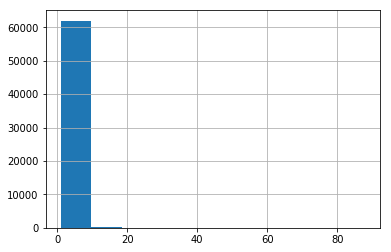

```python
#app_per_patient = df_appointments['PatientId'].value_counts()
# is the number of appointments records for each distinct Patient
app_per_patient.hist()

app_per_patient.describe()
```

```python
outliers = df_appointments.PatientId.value_counts()
outliers[outliers > 10].count()
```

```
248
```

I will have a closer Look at the Patient that took 88 Appointments!

```python
mask_88_times = df_appointments.PatientId.isin(app_per_patient[app_per_patient == 88].index)
df_88Appointments = df_appointments[mask_88_times]

#df_88Appointments.Missed.value_counts().plot(kind='bar')
df_88Appointments.info()
```

```
<class 'pandas.core.frame.DataFrame'>
Int64Index: 88 entries, 26724 to 110483
Data columns (total 14 columns):
PatientId         88 non-null float64
AppointmentID     88 non-null int64
Gender            88 non-null object
ScheduledDay      88 non-null datetime64[ns]
AppointmentDay    88 non-null datetime64[ns]
Age               88 non-null int64
Neighbourhood     88 non-null object
Scholarship       88 non-null int64
Hipertension      88 non-null int64
Diabetes          88 non-null int64
Alcoholism        88 non-null int64
Handcap           88 non-null int64
SMS_received      88 non-null int64
Missed            88 non-null object
dtypes: datetime64[ns](2), float64(1), int64(8), object(3)
memory usage: 10.3+ KB
```

```python
df_88Appointments.head(10)
```

|  | PatientId | AppointmentID | Gender | ScheduledDay | AppointmentDay | Age | Neighbourhood | Scholarship | Hipertension | Diabetes | Alcoholism | Handcap | SMS_received | Missed |
| --- | --- | --- | --- | --- | --- | --- | --- | --- | --- | --- | --- | --- | --- | --- |
| 26724 | 8.221459e+14 | 5638995 | M | 2016-04-29 08:38:44 | 2016-04-29 | 38 | REDENÇÃO | 0 | 0 | 0 | 0 | 0 | 0 | No |
| 27981 | 8.221459e+14 | 5640809 | M | 2016-04-29 11:27:34 | 2016-04-29 | 38 | REDENÇÃO | 0 | 0 | 0 | 0 | 0 | 0 | No |
| 29318 | 8.221459e+14 | 5642878 | M | 2016-04-29 18:02:42 | 2016-04-29 | 38 | REDENÇÃO | 0 | 0 | 0 | 0 | 0 | 0 | No |
| 30893 | 8.221459e+14 | 5645183 | M | 2016-05-02 09:34:46 | 2016-05-02 | 38 | REDENÇÃO | 0 | 0 | 0 | 0 | 0 | 0 | No |
| 33374 | 8.221459e+14 | 5649058 | M | 2016-05-02 17:38:17 | 2016-05-02 | 38 | REDENÇÃO | 0 | 0 | 0 | 0 | 0 | 0 | No |
| 33431 | 8.221459e+14 | 5649163 | M | 2016-05-02 17:57:36 | 2016-05-02 | 38 | REDENÇÃO | 0 | 0 | 0 | 0 | 0 | 0 | No |
| 37673 | 8.221459e+14 | 5655382 | M | 2016-05-03 16:57:59 | 2016-05-03 | 38 | REDENÇÃO | 0 | 0 | 0 | 0 | 0 | 0 | No |
| 38929 | 8.221459e+14 | 5657205 | M | 2016-05-04 09:03:31 | 2016-05-04 | 38 | REDENÇÃO | 0 | 0 | 0 | 0 | 0 | 0 | No |
| 39916 | 8.221459e+14 | 5658723 | M | 2016-05-04 11:38:34 | 2016-05-04 | 38 | REDENÇÃO | 0 | 0 | 0 | 0 | 0 | 0 | No |
| 39926 | 8.221459e+14 | 5658733 | M | 2016-05-04 11:40:14 | 2016-05-04 | 38 | REDENÇÃO | 0 | 0 | 0 | 0 | 0 | 0 | No |

```python
df_88Appointments.Missed.value_counts()
```

```
No     87
Yes     1
Name: Missed, dtype: int64
```

It looks like this Patient went to almost every single Appointment, and sometimes even 3 times a day! This seems hard to believe. But the Number of this kind of Outliers is insignificant so I think it is ok to just ignore them.

### Inspecting "Single" vs. "Several" Appointments separatly:

Let's have a Look at how many People missed their single Appointment:

```
No     30802
Yes     7118
Name: Missed, dtype: int64
```

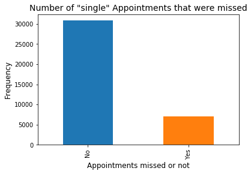

```python
missed_single = df_once.Missed.value_counts()
print(missed_single)
missed_single.plot(kind='bar');
plt.title('Number of "single" Appointments that were missed', fontsize=14)
plt.xlabel('Appointments missed or not', fontsize=12)
plt.ylabel('Frequency', fontsize=12)
```

Now let's look at the same Proportion for the Appointments made several times for a same Patient:

```
No     57406
Yes    15201
Name: Missed, dtype: int64
```

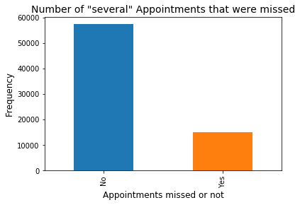

```python
missed_several = df_several.Missed.value_counts()
print(missed_several)
missed_several.plot(kind='bar');
plt.title('Number of "several" Appointments that were missed', fontsize=14)
plt.xlabel('Appointments missed or not', fontsize=12)
plt.ylabel('Frequency', fontsize=12)
```

## Exploratory Data Analysis

### Inspecting Dataframe for the missed Appointments vs. met Appointments

I will group the Dataset in two subsets, for missed and non-missed Appointments and look at statistics and basic plots (histograms and bar charts) of both Groups, to get an Overview and ideas of which Features I should further inspect.

|  | PatientId | AppointmentID | Age | Scholarship | Hipertension | Diabetes | Alcoholism | Handcap | SMS_received |
| --- | --- | --- | --- | --- | --- | --- | --- | --- | --- |
| count | 2.231900e+04 | 2.231900e+04 | 22319.000000 | 22319.000000 | 22319.000000 | 22319.000000 | 22319.000000 | 22319.000000 | 22319.000000 |
| mean | 1.467523e+14 | 5.652259e+06 | 34.317667 | 0.115507 | 0.169004 | 0.064071 | 0.030333 | 0.020297 | 0.438371 |
| std | 2.549905e+14 | 7.429686e+04 | 21.965941 | 0.319640 | 0.374764 | 0.244885 | 0.171505 | 0.156670 | 0.496198 |
| min | 5.628261e+06 | 5.122866e+06 | 0.000000 | 0.000000 | 0.000000 | 0.000000 | 0.000000 | 0.000000 | 0.000000 |
| 25% | 4.176779e+12 | 5.614192e+06 | 16.000000 | 0.000000 | 0.000000 | 0.000000 | 0.000000 | 0.000000 | 0.000000 |
| 50% | 3.156794e+13 | 5.657916e+06 | 33.000000 | 0.000000 | 0.000000 | 0.000000 | 0.000000 | 0.000000 | 0.000000 |
| 75% | 9.454270e+13 | 5.703175e+06 | 51.000000 | 0.000000 | 0.000000 | 0.000000 | 0.000000 | 0.000000 | 1.000000 |
| max | 9.996585e+14 | 5.789986e+06 | 115.000000 | 1.000000 | 1.000000 | 1.000000 | 1.000000 | 4.000000 | 1.000000 |

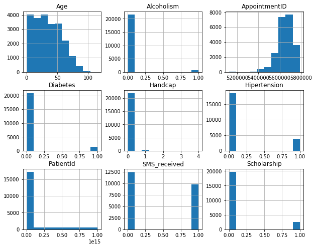

```python
df_missed = df_appointments.query('Missed == "Yes"')
df_showed_up = df_appointments.query('Missed == "No"')

df_missed.hist(figsize=(10,8));
df_missed.describe()
```

|  | PatientId | AppointmentID | Age | Scholarship | Hipertension | Diabetes | Alcoholism | Handcap | SMS_received |
| --- | --- | --- | --- | --- | --- | --- | --- | --- | --- |
| count | 8.820800e+04 | 8.820800e+04 | 88208.000000 | 88208.000000 | 88208.000000 | 88208.000000 | 88208.000000 | 88208.000000 | 88208.000000 |
| mean | 1.476845e+14 | 5.681137e+06 | 37.790064 | 0.093903 | 0.204392 | 0.073837 | 0.030417 | 0.022742 | 0.291334 |
| std | 2.563747e+14 | 6.931225e+04 | 23.338878 | 0.291695 | 0.403259 | 0.261507 | 0.171732 | 0.162750 | 0.454380 |
| min | 3.921784e+04 | 5.030230e+06 | -1.000000 | 0.000000 | 0.000000 | 0.000000 | 0.000000 | 0.000000 | 0.000000 |
| 25% | 4.168386e+12 | 5.646218e+06 | 18.000000 | 0.000000 | 0.000000 | 0.000000 | 0.000000 | 0.000000 | 0.000000 |
| 50% | 3.176184e+13 | 5.685684e+06 | 38.000000 | 0.000000 | 0.000000 | 0.000000 | 0.000000 | 0.000000 | 0.000000 |
| 75% | 9.433715e+13 | 5.731078e+06 | 56.000000 | 0.000000 | 0.000000 | 0.000000 | 0.000000 | 0.000000 | 1.000000 |
| max | 9.999816e+14 | 5.790484e+06 | 115.000000 | 1.000000 | 1.000000 | 1.000000 | 1.000000 | 4.000000 | 1.000000 |

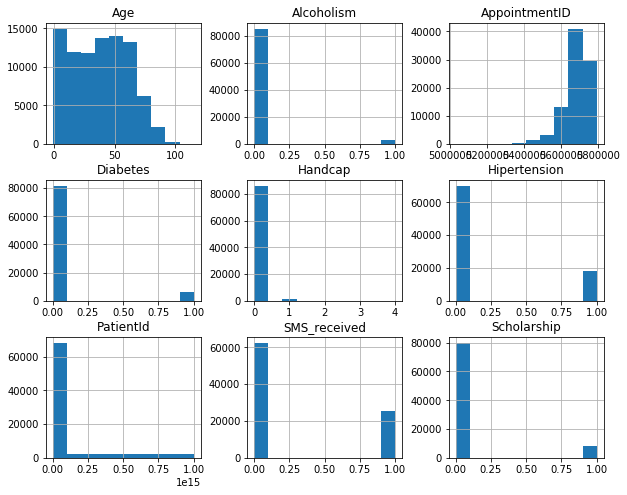

```python
df_showed_up.hist(figsize=(10,8))
df_showed_up.describe()
```

#### **Impression on the basic Charts and Decision for Investigation:**

I would have expected to see more obvious Differences when comparing the Charts to each other. In particular the Charts showing the Amount of Dieseases, Handcap and Scholarship does not show obvious Tendencies, in fact they look very similar in both Cases, where Appointments were attended or missed.  
**So I decided to focus my Investigation on the Variables of "Age", "Gender" and "Neighbourhood".**

### Research Question 1: Does the Age play a Role in missing an Appointment?

Let's look at the Age Distribution for the whole Dataset

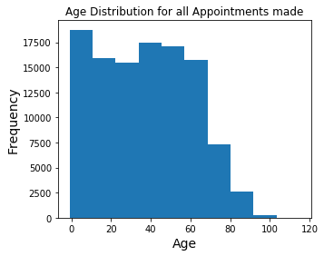

```python
df_appointments.Age.plot(kind='hist', figsize=(5,4))
plt.xlabel('Age', fontsize=14)
plt.ylabel('Frequency', fontsize=14)
plt.title('Age Distribution for all Appointments made')
```

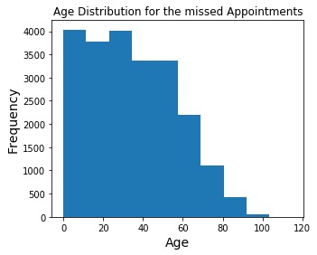

```python
df_missed.Age.plot(kind='hist', figsize=(5,4))
plt.xlabel('Age', fontsize=14)
plt.ylabel('Frequency', fontsize=14)
plt.title('Age Distribution for the missed Appointments')
```

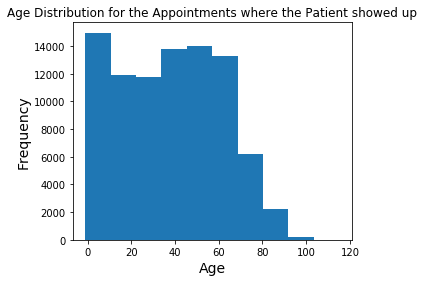

```python
df_showed_up.Age.plot(kind='hist', figsize=(5,4))
plt.xlabel('Age', fontsize=14)
plt.ylabel('Frequency', fontsize=14)
plt.title('Age Distribution for the Appointments where the Patient showed up')
```

The Tendency I can observe, is that a bigger Proportion of Patients between 10 and 30 years old, seem to miss their Appointments. Let's see if can verify this Observation.

```python
df_appointments.head()
```

|  | PatientId | AppointmentID | Gender | ScheduledDay | AppointmentDay | Age | Neighbourhood | Scholarship | Hipertension | Diabetes | Alcoholism | Handcap | SMS_received | Missed |
| --- | --- | --- | --- | --- | --- | --- | --- | --- | --- | --- | --- | --- | --- | --- |
| 0 | 8.322564e+14 | 5030230 | F | 2015-11-10 07:13:56 | 2016-05-04 | 51 | RESISTÊNCIA | 0 | 0 | 0 | 0 | 0 | 1 | No |
| 1 | 9.163747e+13 | 5122866 | M | 2015-12-03 08:17:28 | 2016-05-02 | 34 | VILA RUBIM | 0 | 1 | 0 | 0 | 0 | 1 | Yes |
| 2 | 1.216587e+12 | 5134197 | F | 2015-12-07 10:40:59 | 2016-06-03 | 27 | SÃO CRISTÓVÃO | 1 | 0 | 0 | 0 | 0 | 1 | Yes |
| 3 | 3.189960e+13 | 5134220 | F | 2015-12-07 10:42:42 | 2016-06-03 | 48 | MARUÍPE | 0 | 1 | 1 | 0 | 0 | 1 | No |
| 4 | 9.582232e+12 | 5134223 | F | 2015-12-07 10:43:01 | 2016-06-03 | 80 | SÃO CRISTÓVÃO | 0 | 1 | 1 | 0 | 0 | 1 | No |

I will add a new Column 'Age Level', containing a categorical value in ['kid', 'young', adult, elderly] , to be able to group my Appointments within these Age Levels: ([0, 10], [10, 30], [30, 70], [70,115]). These being the groups with similar Values, I can identify from the Graphs.

```python
bin_edges= [0,10,30,70,115]
bin_names= ['kid', 'young', 'adult', 'elderly']
df_appointments['Age_Level']= pd.cut(df_appointments['Age'], bins=bin_edges, labels=bin_names, include_lowest=True)
df_appointments.head()
```

|  | PatientId | AppointmentID | Gender | ScheduledDay | AppointmentDay | Age | Neighbourhood | Scholarship | Hipertension | Diabetes | Alcoholism | Handcap | SMS_received | Missed | Age_Level |
| --- | --- | --- | --- | --- | --- | --- | --- | --- | --- | --- | --- | --- | --- | --- | --- |
| 0 | 8.322564e+14 | 5030230 | F | 2015-11-10 07:13:56 | 2016-05-04 | 51 | RESISTÊNCIA | 0 | 0 | 0 | 0 | 0 | 1 | No | adult |
| 1 | 9.163747e+13 | 5122866 | M | 2015-12-03 08:17:28 | 2016-05-02 | 34 | VILA RUBIM | 0 | 1 | 0 | 0 | 0 | 1 | Yes | adult |
| 2 | 1.216587e+12 | 5134197 | F | 2015-12-07 10:40:59 | 2016-06-03 | 27 | SÃO CRISTÓVÃO | 1 | 0 | 0 | 0 | 0 | 1 | Yes | young |
| 3 | 3.189960e+13 | 5134220 | F | 2015-12-07 10:42:42 | 2016-06-03 | 48 | MARUÍPE | 0 | 1 | 1 | 0 | 0 | 1 | No | adult |
| 4 | 9.582232e+12 | 5134223 | F | 2015-12-07 10:43:01 | 2016-06-03 | 80 | SÃO CRISTÓVÃO | 0 | 1 | 1 | 0 | 0 | 1 | No | elderly |

```python
# adding 'include_lowest = True' in the cut Function, prevents getting null values for all
# Babies (Patients of Age zero). I confirm that I fixed that Problem:
df_appointments.columns.isnull().any()
```

```
False
```

Now I can group my two Dataframes, the one with all missed Appointments and the one where Appointments were met, with these Age Levels to see the number of met/missed Appointments for each age group. I can then make a Bar graph to see the Proportions in percents for each Age Level.

```
Age_Level
kid        14961
young      20180
adult      45851
elderly     7215
Name: Gender, dtype: int64
Age_Level
kid         3788
young       6702
adult      10471
elderly     1358
Name: Gender, dtype: int64
Age_Level
kid        18749
young      26882
adult      56322
elderly     8573
Name: Gender, dtype: int64
```

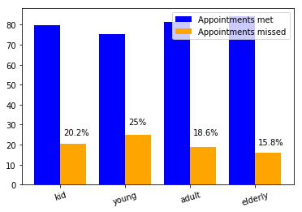

```python
# we have to update our dataframes to include the new 'Age_Level' Column:
df_missed = df_appointments.query('Missed == "Yes"')
df_showed_up = df_appointments.query('Missed == "No"')

met_by_age = df_showed_up.groupby('Age_Level').count()['Gender']
missed_by_age = df_missed.groupby('Age_Level').count()['Gender']

print(met_by_age)
print(missed_by_age)

#Make a Bar Graph showing the Proportions of met/missed Appointments for each Age Level:
totalNumber = df_appointments.groupby('Age_Level').count()['Gender']
print(totalNumber)

ind = met_by_age.index
locations = np.arange(len(ind))
wid = 0.4

plt.bar(locations, met_by_age/totalNumber*100, width= wid, label="Appointments met", color='blue')
plt.bar(locations+0.4, missed_by_age/totalNumber*100, width=wid, label="Appointments missed", color='orange')
plt.text(0.25, 25, r'20.2%')
plt.text(01.25, 30, r'25%')
plt.text(02.25, 25, r'18.6%')
plt.text(03.25, 20, r'15.8%')
plt.xticks(locations+0.2, ind, rotation=17)
plt.legend();
```

So the biggest Proportion, in percentage about **25%** of the Appointments, made for the 'young' Patients (between 10 and 30 years) are missed. ('kid': **20.2%**, 'adult': **18.6%**, elderly: **15.8%**) I could verify my Observation.

### Research Question 2: Does the Gender affect missing an Appointment?

#### Inspecting the Dataframe corresponding to unique Appointments made by a Patient. (Proportions of Women vs. Men are not biased, as one Record corresponds to one Patient)

So we are now working on the dataframe 'df_once' that we extracted before.

First get the needed Data and make a Pie Chart to see Women Proportions.

```
F    23675
M    14245
Name: Gender, dtype: int64
Appointments missed by Women:
No     19272
Yes     4403
Name: Missed, dtype: int64

Appointments missed by Men:
No     11530
Yes     2715
Name: Missed, dtype: int64
```

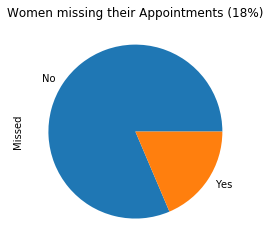

```python
# see proportions of men and women
print(df_once.Gender.value_counts())

df_women_once = df_once[df_once['Gender'] == "F"]
df_men_once = df_once[df_once['Gender'] == "M"]

print('Appointments missed by Women:\n{0}\n'.format(df_women_once.Missed.value_counts()))
print('Appointments missed by Men:\n{0}\n'.format(df_men_once.Missed.value_counts()))

df_women_once.Missed.value_counts().plot(kind='pie')
plt.title('Women missing their Appointments ({0}%)'.format(int(4403/23675*100)));
```

Let's do the same to see the Proportions of Men:

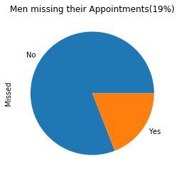

```python
df_men_once.Missed.value_counts().plot(kind='pie')
plt.title('Men missing their Appointments({0}%)'.format(int(2715/14245*100)))
```

As the Proportions are about the same, between Women and Men, it seems that 'Gender' is not a Characteristic influencing our Outcome.

### Research Question 3: Does the Location of the Clinic affect missing an Appointment?

So we will now investigate on the 'Neighbourhood' Feature.

```python
df_missed.columns
```

```
Index(['PatientId', 'AppointmentID', 'Gender', 'ScheduledDay',
       'AppointmentDay', 'Age', 'Neighbourhood', 'Scholarship', 'Hipertension',
       'Diabetes', 'Alcoholism', 'Handcap', 'SMS_received', 'Missed',
       'Age_Level'],
      dtype='object')
```

```python
len(df_missed.Neighbourhood.value_counts().index)
```

```
80
```

```python
len(df_showed_up.Neighbourhood.value_counts().index)
```

```
80
```

As there are 80 different Locations, we want to look for the first 10 Neighbourhoods for both Dataframes and make a Pie Chart of the Proportions of Appointments (missed/showed-up)made in these Neighbourhoods. Then we can compare both and see if we can make any Observations.

I first chose 10 colours for the first Pie Chart from the [xkcd color name survey](https://xkcd.com/color/rgb/)

```python
col = ['xkcd:blue','xkcd:orange','xkcd:green','xkcd:red','xkcd:grey','xkcd:sky blue','xkcd:khaki',
       'xkcd:turquoise','xkcd:dark pink', 'xkcd:lavender']
```

I make a Pie Chart for the Appointments missed in the main 10 Neighbourhoods, where these Appointments were made:

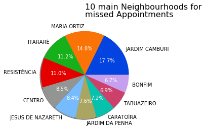

```python
missed_first_ten_loc = df_missed.Neighbourhood.value_counts()[:10]
showed_up_first_ten = df_showed_up.Neighbourhood.value_counts()[:10]

patches, texts, autotexts = plt.pie(missed_first_ten_loc, labels=missed_first_ten_loc.index,
                                     colors=col, shadow=True, autopct='%1.1f%%')
for text in autotexts:
    text.set_color('white')
    text.set_fontsize(10)
ax1_title= '10 main Neighbourhoods for\nmissed Appointments'
plt.title(horizontalalignment='left', label=ax1_title, fontsize=16, linespacing=1)
```

I want to keep the same colours for the same Neighbourhoods to help comparing the two pie charts.

```python
missed_first_ten_loc.index.isin(showed_up_first_ten.index)
```

```
array([ True,  True,  True,  True,  True, False,  True, False,  True,
        True])
```

As there are 2 Neighbourhoods in the "missed" Dataframe that are not in the "showed-up" Dataframe ('JESUS DE NAZARETH' and 'CARATOÍRA'), I will have to take two other colours for the second Pie Chart (for SANTA MARTHA and SANTO ANTÔNIO) as keeping the same colours for the same Neighbourhoods help comparing the two Pie Charts.

```python
missed_first_ten_loc
```

```
JARDIM CAMBURI       1465
MARIA ORTIZ          1219
ITARARÉ               923
RESISTÊNCIA           906
CENTRO                703
JESUS DE NAZARETH     696
JARDIM DA PENHA       631
CARATOÍRA             591
TABUAZEIRO            573
BONFIM                550
Name: Neighbourhood, dtype: int64
```

```python
showed_up_first_ten
```

```
JARDIM CAMBURI     6252
MARIA ORTIZ        4586
RESISTÊNCIA        3525
JARDIM DA PENHA    3246
SANTA MARTHA       2635
CENTRO             2631
ITARARÉ            2591
TABUAZEIRO         2559
SANTO ANTÔNIO      2262
BONFIM             2223
Name: Neighbourhood, dtype: int64
```

```python
col = ['xkcd:blue','xkcd:orange','xkcd:red', 'xkcd:khaki','xkcd:salmon','xkcd:grey','xkcd:green',
       'xkcd:dark pink','xkcd:light pink', 'xkcd:lavender']
```

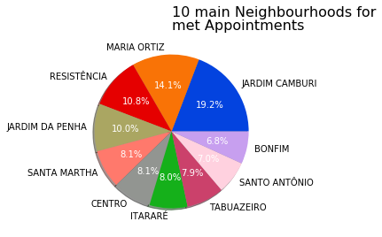

```python
patches, texts, autotexts = plt.pie(showed_up_first_ten, labels=showed_up_first_ten.index,
                                     colors=col, shadow=True, autopct='%1.1f%%')
for text in autotexts:
    text.set_color('white')
    text.set_fontsize(10)
ax1_title= '10 main Neighbourhoods for\nmet Appointments'
plt.title(horizontalalignment='left', label=ax1_title, fontsize=16, linespacing=1)
```

I can observe that 'ITARARÉ' is one of the first 4 Neighbourhoods were Appointments were missed and two Neighbourhoods appear specifically in the first ten main Neighbourhoods were Appointments were missed ('JESUS DE NAZARETH' and 'CARATOÍRA'). I want to see if all Appointments that were made in these 3 Neighbourhoods tend to be more missed.

```python
df_specific_Hood = df_appointments.query('Neighbourhood in ["ITARARÉ", "JESUS DE NAZARETH", "CARATOÍRA"]')
df_specific_Hood.head()
```

|  | PatientId | AppointmentID | Gender | ScheduledDay | AppointmentDay | Age | Neighbourhood | Scholarship | Hipertension | Diabetes | Alcoholism | Handcap | SMS_received | Missed | Age_Level |
| --- | --- | --- | --- | --- | --- | --- | --- | --- | --- | --- | --- | --- | --- | --- | --- |
| 62 | 2.721818e+13 | 5209081 | M | 2016-01-04 09:08:46 | 2016-05-09 | 19 | CARATOÍRA | 0 | 0 | 0 | 0 | 0 | 0 | Yes | young |
| 87 | 3.213257e+13 | 5244931 | M | 2016-01-13 08:12:12 | 2016-05-11 | 21 | CARATOÍRA | 1 | 0 | 0 | 0 | 0 | 1 | No | young |
| 92 | 3.217853e+12 | 5269411 | M | 2016-01-20 08:35:57 | 2016-05-02 | 69 | CARATOÍRA | 0 | 1 | 0 | 0 | 1 | 1 | No | adult |
| 107 | 3.774965e+13 | 5285153 | M | 2016-01-25 11:56:26 | 2016-05-16 | 89 | JESUS DE NAZARETH | 0 | 0 | 0 | 0 | 0 | 0 | No | elderly |
| 130 | 9.775623e+10 | 5311326 | M | 2016-02-01 11:56:10 | 2016-05-04 | 77 | ITARARÉ | 0 | 1 | 0 | 0 | 0 | 1 | No | elderly |

```python
df_specific_Hood.Missed.value_counts()
```

```
No     6722
Yes    2210
Name: Missed, dtype: int64
```

```python
df_ITA = df_appointments.query('Neighbourhood == "ITARARÉ"')
df_ITA.Missed.value_counts()
```

```
No     2591
Yes     923
Name: Missed, dtype: int64
```

```python
df_JESUS = df_appointments.query('Neighbourhood == "JESUS DE NAZARETH"')
df_JESUS.Missed.value_counts()
```

```
No     2157
Yes     696
Name: Missed, dtype: int64
```

```python
df_CARA = df_appointments.query('Neighbourhood == "CARATOÍRA"')
df_CARA.Missed.value_counts()
```

```
No     1974
Yes     591
Name: Missed, dtype: int64
```

```python
df_main_Hood = df_appointments.query('Neighbourhood in ["JARDIM CAMBURI", "MARIA ORTIZ", "RESISTÊNCIA"]')
df_main_Hood.Missed.value_counts()
```

```
No     14363
Yes     3590
Name: Missed, dtype: int64
```

I can see that **24.7%** of the Appointments arranged in the Neighbourhoods of either "ITARARÉ", "JESUS DE NAZARETH"or "CARATOÍRA" were missed. **26.3%** of the Appointments made in "ITARARÉ" were missed, **24.4%** of the Appointments made in "JESUS DE NAZARETH" were missed, **23%** of the Appointments made in "CARATOÍRA" were missed.

## Limitations and Conclusion

### Limitations:

If I could find and show some Tendencies for Patients being more inclined to miss their Appointments, the Factors I was investigating, given the Dataset provided, did not reveal a strong Correlation to the Outcome. Furthermore, I think additional and more specific Factors, describing the Patients, were missing in this Dataset, that could help explaining why an important Proportion of medical Appointments were not attended.

What I imagine, could prevent a Patient to show up at a specific Hospital, could be Factors related to the Distance/Journey this Patient has to travel, for example. So, Information like "how far the patient live from the Hospital", or the Quality of the Traffic/public Transportation could be precious additional Variables. Also, Informations about the financial Wealth of the Patients and how secure, the Areas they have to go to, could be valuable Information to work with (Regarding financial Wealth Information, we only had a Variable indicating if a Patient is registered in a social Program helping the Families most needing financial Help. And this did not reveal much either in Correlation to the Outcome Variable). Also, I could identify a Tendency for the Patients between 10 and 30, being more inclined, to not show up to their Appointments: it could be interesting to have additional Information about the Patients Situation: Do the Kids/Teens go to School/University? Are the young Adults employed?

#### Limitation Conclusion:

So in Addition to the Fact, that we are already limited, while just working with descriptive Statistics and Visuals (compared to inferential Statistics and machine Learning)and just are able to build up Intuition about possible Explanations and Tendencies, I think the Dataset we had to work with, was missing additional valuable Variables, in Order to show stronger Correlations and more interesting Findings.